# Review: MAP

In this report we review the variables in the Memory and Aging Project (MAP) study of RUSH Institute.

# Exposition

This report is a record of interaction with a data transfer object (dto) produced by sequence of scripts

- `./manipulation/map/0-greeter-map.R`
- `./manipulation/map/1-tuner-map.R`
- `./manipulation/map/2-encoder-map.R`
- `./manipulation/map/3-validator-map.R`

Their roles are described in the following chain of custody:

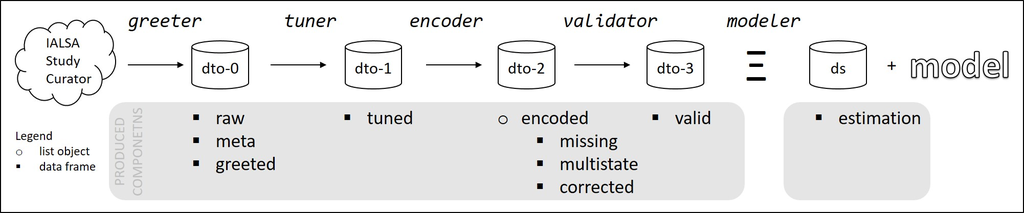

The data set for a longitudinal study prepared by the respective [ialsa-study-curator](https://github.com/IALSA/ialsa-study-curator/blob/master/README.md) enters the analytic environment of the  
[ialsa-2018-amsterdam](https://github.com/IALSA/ialsa-2018-amsterdam/blob/master/README.md) and meets the  
- [greeter](https://github.com/IALSA/ialsa-2018-amsterdam/blob/master/manipulation/map/0-greeter-map.R) script, which adds custom meta-data and shapes the *data transfer object* (dto), which tracks all states of the data on its way to the estimated model (hence, “chain of custody” metaphor).  
- [tuner](https://github.com/IALSA/ialsa-2018-amsterdam/blob/master/manipulation/map/1-tuner-map.R) script, which implements project-specific data transformation is then applied to create variables that could by used by the  
- [encoder](https://github.com/IALSA/ialsa-2018-amsterdam/blob/master/manipulation/map/2-encoder-map.R) script to encode the multistate variable, pivotal for the `msm()` estimation call. Then  
- [validator](https://github.com/IALSA/ialsa-2018-amsterdam/blob/master/manipulation/map/3-validator-map.R) script makes sure only valid cases (respondents) are selected and passes the data to the  
- [modeler](https://github.com/IALSA/ialsa-2018-amsterdam/blob/master/manipulation/map/4-modeler-map.R) script, which estimates the statistical model according the [model-specification](https://github.com/IALSA/ialsa-2018-amsterdam/blob/master/libs/images/support/model-a-specification.jpg) and saves generated objects to local drive.

## Overview of objects

Let us review the data objects in this chain of custody. We will mostly use the `dto$valid` dataset, as the one containing all (and only) necessary variable for our modeling exercise and only those cases/subjects that were considered eligible from the data quality perspective.

```r
dto <- readRDS(path_input)
names(dto)
```

```
[1] "raw"     "meta"    "greeted" "tuned"   "encoded" "valid"
```

```r
# 1st element - dto$raw     - raw data, as obtained from ialsa-study-curator for RUSH-MAP study
# 2nd element - dto$meta    - meta data, info about variables
# 3rd element - dto$greeted - dataset produced by the greeter script
# 4th element - dto$tuned   - dataset produced by the tuner script
# 5th element - dto$encoded - dataset produced by the encoder script
   # dto$encoded is a list consisting of three data frames representing encoding steps
   # dto$encoded$missing    # dataset after encoding missing states (-1, -2)
   # dto$encoded$multistate # dataset after encoding multistates (1,2,3,4)
   # dto$encoded$corrected  # dataset after correcting for longitudinal values
# 6th element - dto$valid   - dataset produced by validator script
# contains only valid case that have been CLEARED to enter the estimation routine
# however, what actually ENTERED model estimation is preserved immediately before msm call
# and stored along side model estimation results (produced by the first part of the `modeler` script):
ds_estimation <- readRDS(path_input_ds_estimation)
# review locations
print(path_input)
```

```
[1] "./data/unshared/derived/dto-3-valid.rds"
```

```r
print(path_input_ds_estimation)
```

```
[1] "./data/unshared/derived/models/ds_estimation.rds"
```

```r
names(dto) # inspect componets in the data transfer object (dto)
```

```
[1] "raw"     "meta"    "greeted" "tuned"   "encoded" "valid"
```

```r
names(dto$encoded) # phases of the encoding procedure
```

```
[1] "missing"    "multistate" "corrected"
```

```r
# create aliases for quick access
# full version of data before any subsetting, filtering or transformations
ds_greeted <- dto$greeted %>% tibble::as_tibble()
# prepared for modeling, only valid cases. all variables needed in place.
ds_valid   <- dto$valid %>% tibble::as_tibble()
```

## Metadata

The `dto` contains the meta data set, descrdibing the existing variables. This spreadsheet is the means by which variables are studied, classified, renamed, described, and annotated. The process of applying this meta data file to alter the `raw` form is described in the `./manipulation/map/0-greeter-map.R` script.

|  | name | label | type | name_new | name_change | construct | self_reported | longitudinal | unit | include | frailty |
| --- | --- | --- | --- | --- | --- | --- | --- | --- | --- | --- | --- |
| 1 | ad_reagan | Dicotomized NIA-Reagan score | pathology | ad_reagan |  | alzheimer | False | False | category |  |  |
| 2 | age_at_visit | Age at cycle - fractional | demographic | age_at_visit |  | age | False | True | year | True |  |
| 3 | age_bl | Age at baseline | demographic | age_at_baseline | True | age | False | False | year | True |  |
| 4 | age_death | Age at death | demographic | age_at_death | True | age | False | False | year | True |  |
| 5 | agreeableness | NEO agreeableness-ROS | personality | agreeableness |  |  | True | False | scale |  |  |
| 6 | alcohol_g_bl | Grams of alcohol used per day at baseline | substance | alcohol_g_bl |  | alcohol | True | False | grams |  |  |
| 7 | anxiety_10items | Anxiety-10 item version - ROS and MAP | personality | anxiety_10items |  | anxiety |  | False | scale |  |  |
| 8 | apoe_genotype | Apolipoprotein E genotype | clinical | apoe_genotype |  | apoe | False | False | category |  |  |
| 9 | bmi | Body mass index | physical | bmi |  | physique | False | True | kg/msq |  | True |
| 10 | bp11 | Blood pressure measurement- sitting - trial 1 | medical | bp_sit_1 | True | hypertension | False | True | scale |  |  |

[output cut: 124 more lines]

## How to interact

Now that the full chain of custody (up until estimation) is loaded into our analytic environment, we can demonstrate some of the ways we can interact with `dto` to set the stage for data visualization to follow.

```r
# this is how we can interact with the `dto` to call and graph data and metadata
dto$meta %>%
  dplyr::filter(type=="demographic") %>%
  dplyr::select(name,name_new,label)

dto$valid %>% dplyr::glimpse(90)
```

[output not shown]

## Valid vs Estimated

> What is the difference between `dto$valid` and `ds_estimation`?

If all eligible cases (from perspective of data cleanliness) are employed during estimation, these two data sets should contain identical set of cases (repsondents).

> Why do we want to differentiate between `dto$valid` and `ds_estimation`?

During the search for the final model to be reported, we may want to compare various nuanced subsamples (e.g. dropping those with intermidiate missing state) and subcohorts (e.g. gender and race). To have this flexibity in the workflow, yet capture this nuance in the documentation `dto$valid` and `ds_estimation`

```r
# identifiy the difference between eligible cases and those used in estimation (2 steps):
# identify cases CLEARED for modeling
valid_ids <-
  dto$valid %>%
  dplyr::distinct(id) %>%
  as.list() %>% unlist() %>% as.vector()

valid_ids %>% length()
```

```
[1] 1728
```

```r
# identify cases USED in estimation
modeled_ids <-
  ds_estimation %>%
  dplyr::distinct(id) %>%
  as.list() %>% unlist() %>% as.vector()

modeled_ids %>% length()
```

```
[1] 1728
```

```r
# Has the model in question used all legal cases? In other words, how many cases did not enter estimation adn are unique to `dto$valid`?
(unique_to_valid <- setdiff(modeled_ids, valid_ids))
```

```
integer(0)
```

```r
# Of all valid cases cleared for estimation
(n_valid <- valid_ids %>% length())
```

```
[1] 1728
```

```r
# How many were used during estimation of this model?
(n_modeled <- n_valid - length( setdiff(modeled_ids, valid_ids) ) )
```

```
[1] 1728
```

```r
# which means that ds_estimation dropped
(n_valid - n_modeled)
```

```
[1] 0
```

```r
# eligible cases from the dto$valid state of the data
```

## Contents

To be explicit about the content of the focal data set for this report, we list its geneology and local transformations in the following call.

```r
# variablables - only those relevant to the research question
# listing variables is useful to remind the contents and update the order
# this listing was adapted from the initial mention in `1-tuner-map.R`
ds <- dto$valid %>%
  dplyr::filter(id %in% modeled_ids) %>%
  dplyr::mutate_(
    "age_at_visit" = "age" # `msm` required this variable to have standard name `age`
  ) %>%
  dplyr::select_(
    "id"             # personal identifier
    ,"male"          # gender
    ,"edu"           # years of education
    ,"birth_year"    # year of birth
    ,"died"          # death indicator
    ,"age_at_death"  # age at death
    ,"age_at_bl"     # age at baseline
    # Temporally flattened meausures: median across observed lifespan
    ,"htm_med"       # height in meters
    ,"bmi_med"       # Body Mass Index
    ,"physact_med"   # Physical activity
    ,"gait_med"      # Gait Speed in minutes per second (min/sec)
    ,"grip_med"      # Extremity strength in pounds (lbs)
    # Temporally flattened meausures: at baseline
    ,"htm_bl"        # height in meters
    ,"bmi_bl"        # Body Mass Index
    ,"physact_bl"    # Physical activity
    ,"gait_bl"       # Gait Speed in minutes per second (min/sec)
    ,"grip_bl"       # Extremity strength in pounds (lbs)
    # time-invariant above
    ,"wave"          # Follow-up year --- --- --- --- --- --- --- --- --- ---
    ,"fu_year"       # Follow-up year --- --- --- --- --- --- --- --- --- ---
    # time-variant below
    ,"firstobs"      # indicator of first observation for a person
    ,"date_at_visit" # perturbed date of visit
    ,"age_at_visit"  # age at cycle - fractional
    ,"age"           # same as above, but standardized name for `msm` consumption
    ,"htm"           # height in meters
    ,"bmi"           # Body Mass Index  in kilograms per meter squared (kg/msq)
    ,"physact"       # Physical activity (sum of 5 items)
    ,"gait"          # Gait Speed in minutes per second (min/sec)
    ,"grip"          # Extremity strength in pounds (lbs)
    ,"cogn_global"   # global cognition
    ,"dementia"      # dementia diagnosis (?)
    ,"mmse"          # mini mental state exam (max =30)
    ,"state"         # multistate variable created for model
  )
```

Now that the `valid` data set is loaded up into our environment and we understand its relationship to `ds_estimation` we can look at what data displays for individual cases.

```r
head(ds)
```

```
    id  male edu birth_year died age_at_death age_at_bl  htm_med  bmi_med physact_med gait_med grip_med   htm_bl
1 9121 FALSE  12       1930    0           NA  79.96988 1.778004 26.97526        1.25  0.48768     39.5 1.778004
2 9121 FALSE  12       1930    0           NA  79.96988 1.778004 26.97526        1.25  0.48768     39.5 1.778004
3 9121 FALSE  12       1930    0           NA  79.96988 1.778004 26.97526        1.25  0.48768     39.5 1.778004
4 9121 FALSE  12       1930    0           NA  79.96988 1.778004 26.97526        1.25  0.48768     39.5 1.778004
5 9121 FALSE  12       1930    0           NA  79.96988 1.778004 26.97526        1.25  0.48768     39.5 1.778004
6 9121 FALSE  12       1930    0           NA  79.96988 1.778004 26.97526        1.25  0.48768     39.5 1.778004
    bmi_bl physact_bl   gait_bl grip_bl wave fu_year firstobs date_at_visit age_at_visit      age      htm      bmi
1 26.83177       1.75 0.4393514      41    0       0        1    2010-06-01     79.96988 79.96988 1.778004 26.83177
2 26.83177       1.75 0.4393514      41    1       1        0    2011-07-12     81.08145 81.08145 1.752604 27.61514
3 26.83177       1.75 0.4393514      41    2       2        0    2012-01-22     81.61259 81.61259 1.778004 26.97526
4 26.83177       1.75 0.4393514      41    3       3        0    2013-01-14     82.59548 82.59548 1.778004 26.40132
5 26.83177       1.75 0.4393514      41    4       4        0    2014-01-14     83.59480 83.59480 1.549403 35.14448
6 26.83177       1.75 0.4393514      41    5       5        0    2015-01-18     84.60507 84.60507 1.778004 25.97086
    physact      gait  grip cogn_global dementia mmse state
1 1.7500000 0.4393514 41.00  0.28671548        0   29     1
2 4.0416667        NA 41.00  0.28229571        0   29     1
3 0.6250000        NA 35.50  0.09356106        0   30     1
4 0.4583333 0.4876800    NA  0.37192905        0   30     1
5 2.1666667 0.3483429 25.75  0.37671155        0   29     1
6 1.2500000 0.5080000 39.50  0.16575760        0   30     1
```

```r
ds$id %>% unique() %>% length() # number of unique ids in ds
```

```
[1] 1728
```

```r
ds %>% dplyr::glimpse(90)
```

```
Observations: 12,279
Variables: 32
$ id            <int> 9121, 9121, 9121, 9121, 9121, 9121, 9121, 33027, 33027, 204228,...
$ male          <lgl> FALSE, FALSE, FALSE, FALSE, FALSE, FALSE, FALSE, FALSE, FALSE, ...
$ edu           <dbl> 12, 12, 12, 12, 12, 12, 12, 14, 14, 8, 8, 8, 8, 8, 8, 8, 8, 22,...
$ birth_year    <dbl> 1930, 1930, 1930, 1930, 1930, 1930, 1930, 1922, 1922, 1941, 194...
$ died          <dbl> 0, 0, 0, 0, 0, 0, 0, 0, 0, 0, 0, 0, 0, 0, 0, 0, 0, 0, 0, 1, 1, ...
$ age_at_death  <dbl> NA, NA, NA, NA, NA, NA, NA, NA, NA, NA, NA, NA, NA, NA, NA, NA,...
$ age_at_bl     <dbl> 79.96988, 79.96988, 79.96988, 79.96988, 79.96988, 79.96988, 79....
$ htm_med       <dbl> 1.778004, 1.778004, 1.778004, 1.778004, 1.778004, 1.778004, 1.7...
$ bmi_med       <dbl> 26.97526, 26.97526, 26.97526, 26.97526, 26.97526, 26.97526, 26....
$ physact_med   <dbl> 1.250000, 1.250000, 1.250000, 1.250000, 1.250000, 1.250000, 1.2...
$ gait_med      <dbl> 0.4876800, 0.4876800, 0.4876800, 0.4876800, 0.4876800, 0.487680...
$ grip_med      <dbl> 39.50, 39.50, 39.50, 39.50, 39.50, 39.50, 39.50, 59.00, 59.00, ...
$ htm_bl        <dbl> 1.778004, 1.778004, 1.778004, 1.778004, 1.778004, 1.778004, 1.7...
```

[output cut: 19 more lines]

```r
ds %>% dplyr::filter(id==33027) %>% as.data.frame()
```

```
     id  male edu birth_year died age_at_death age_at_bl  htm_med  bmi_med physact_med  gait_med grip_med   htm_bl
1 33027 FALSE  14       1922    0           NA  81.00753 1.574803 34.71962           0 0.4828515       59 1.600203
2 33027 FALSE  14       1922    0           NA  81.00753 1.574803 34.71962           0 0.4828515       59 1.600203
    bmi_bl physact_bl   gait_bl grip_bl wave fu_year firstobs date_at_visit age_at_visit      age      htm      bmi
1 32.59422          0 0.4828515      59    0       0        1    2003-07-01     81.00753 81.00753 1.600203 32.59422
2 32.59422          0 0.4828515      59    1       1        0    2004-08-15     82.13552 82.13552 1.549403 36.84502
  physact      gait grip cogn_global dementia mmse state
1       0 0.4828515   59  -0.1107831        0   29     1
2       0        NA   NA          NA       NA   -2    -2
```

```r
ds %>% dplyr::filter(id==402800) %>% as.data.frame()
```

```
      id  male edu birth_year died age_at_death age_at_bl  htm_med  bmi_med physact_med  gait_med grip_med   htm_bl
1 402800 FALSE  16       1934    1     80.65708  78.69131 1.587503 17.27642    2.270833 0.5418667   29.125 1.574803
2 402800 FALSE  16       1934    1     80.65708  78.69131 1.587503 17.27642    2.270833 0.5418667   29.125 1.574803
3 402800 FALSE  16       1934    1     80.65708  78.69131 1.587503 17.27642    2.270833 0.5418667   29.125 1.574803
    bmi_bl physact_bl   gait_bl grip_bl wave fu_year firstobs date_at_visit age_at_visit      age      htm      bmi
1 17.19287   2.708333 0.5418667      31    0       0        1    2012-09-01     78.69131 78.69131 1.574803 17.19287
2 17.19287   2.708333 0.5418667      31    1       1        0    2013-09-05     79.70157 79.70157 1.600203 17.35997
3 17.19287   2.708333 0.5418667      31    0      NA        1    2012-09-01     80.65708 80.65708 1.574803 17.19287
   physact      gait  grip cogn_global dementia mmse state
1 2.708333 0.5418667 31.00   -1.410848        1   17     3
2 1.833333        NA 27.25   -1.854074        1   13     3
3 2.708333 0.5418667 31.00   -1.410848        1   NA     4
```

```r
# subset a smaller cohort for testing
set.seed(41)
sample_size <- 100
ids <- sample(ds$id,300)
# d <- ds %>% dplyr::filter(id %in% ids)
# ds <- ds %>% dplyr::filter(id %in% ids)
```

# Age

## Intervals

```r
# Time intervals in data:
# the age difference between timepoint for each individual
intervals <- matrix(NA,nrow(ds),2)
for(i in 2:nrow(ds)){
  if(ds$id[i]==ds$id[i-1]){
    intervals[i,1] <- ds$id[i]
    intervals[i,2] <- ds$age[i]-ds$age[i-1]
  }
  intervals <- as.data.frame(intervals)
  colnames(intervals) <- c("id", "interval")
}
cat("\n Minimum interval length : ",min(intervals[,2], na.rm=T))
```

```
 Minimum interval length :  0.00273785
```

```r
cat("\n Maximum interval length : ", max(intervals[,2], na.rm=T))
```

```
 Maximum interval length :  11.86858
```

```r
# the age difference between timepoint for each individual
intervals <- intervals[!is.na(intervals[,2]),] # Remove NAs:
cat("\nTime intervals between observations within individuals:\n")
```

```
Time intervals between observations within individuals:
```

```r
print(round(quantile(intervals[,2]),digits))
```

```
   0%   25%   50%   75%  100%
 0.00  0.97  1.00  1.03 11.87
```

```r
# Info on age and time between observations:
cat("\n Graphs of age distribution :\n")
```

```
 Graphs of age distribution :
```

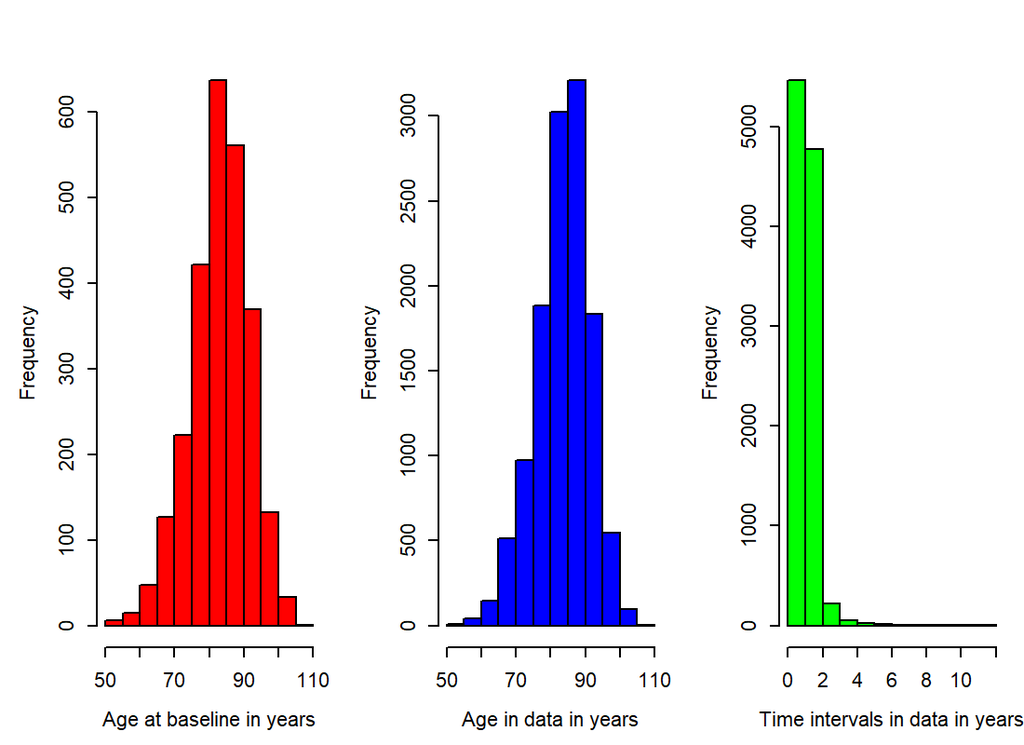

```r
opar<-par(mfrow=c(1,3), mex=0.8,mar=c(5,5,3,1))
hist(ds$age[ds$firstobs==1],col="red",xlab="Age at baseline in years",main="")
hist(ds$age,col="blue",xlab="Age in data in years",main="")
hist(intervals[,2],col="green",xlab="Time intervals in data in years",main="")
```

```r
opar<-par(mfrow=c(1,1), mex=0.8,mar=c(5,5,2,1))
```

## Age at Baseline

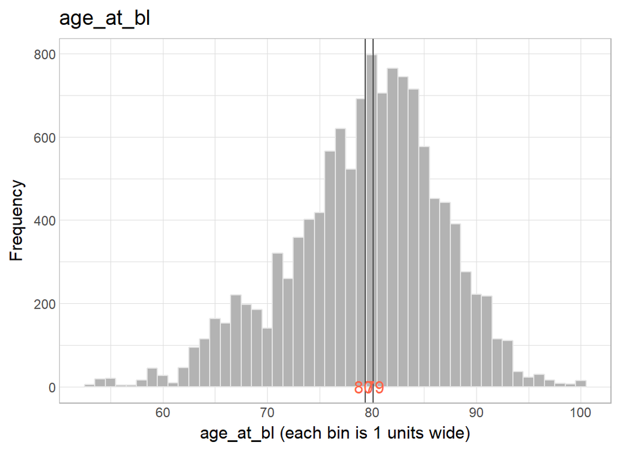

```r
ds %>% histogram_continuous("age_at_bl", bin_width=1)
```

## Year of Birth

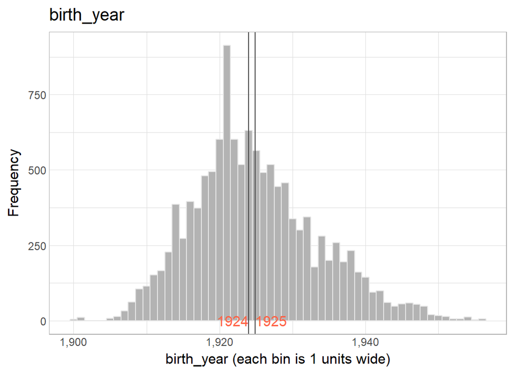

```r
ds %>% histogram_continuous("birth_year", bin_width=1)
```

## Age at Death

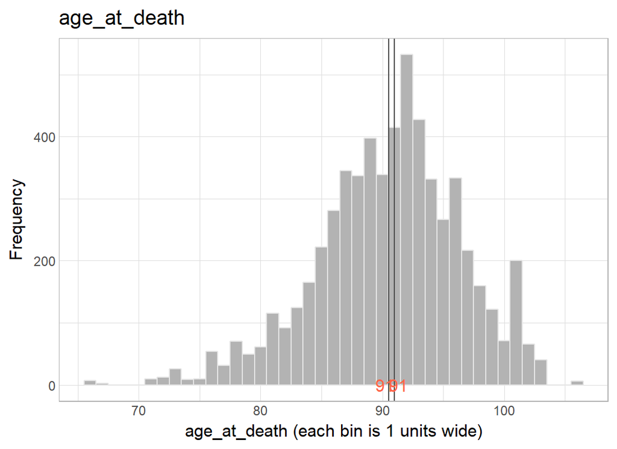

```r
ds %>% histogram_continuous("age_at_death", bin_width=1)
```

## Death indicator

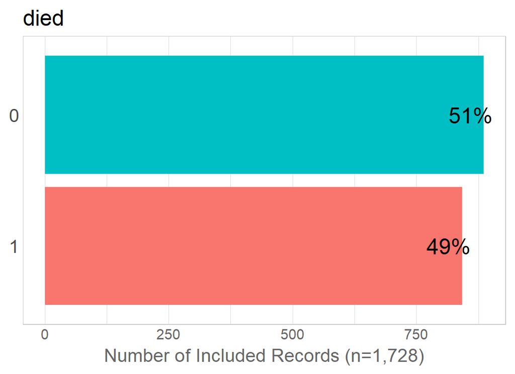

```r
ds %>% dplyr::distinct(id,died) %>% histogram_discrete("died")
```

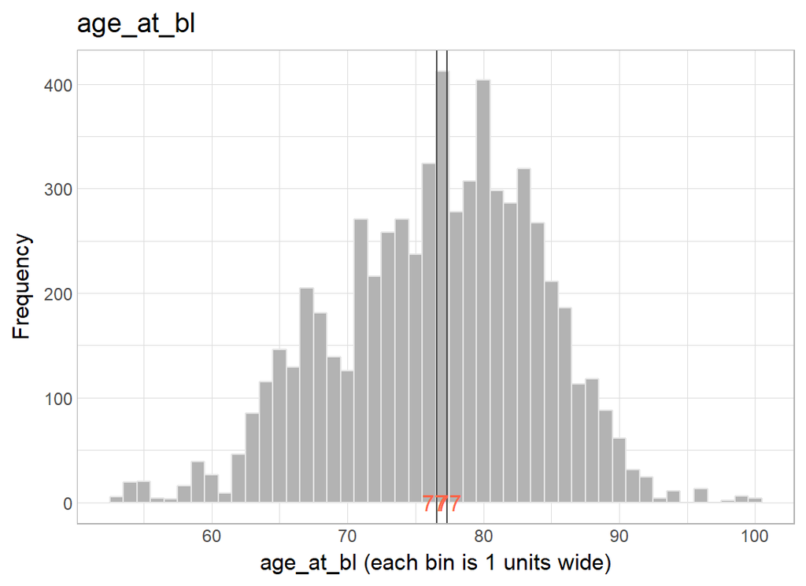

```r
# Age at baseline for those who we know have not died yet
ds %>% dplyr::filter(died==0) %>% histogram_continuous("age_at_bl", bin_width=1)
```

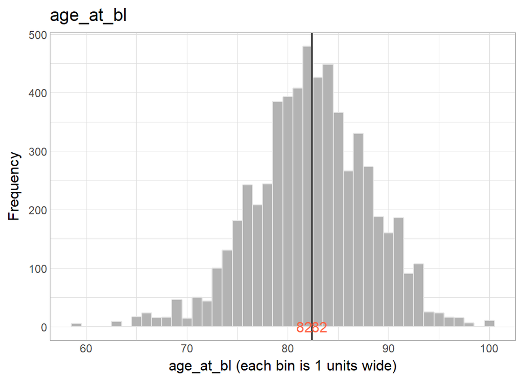

```r
# Age at baseline for those who we know have died
ds %>% dplyr::filter(died==1) %>% histogram_continuous("age_at_bl", bin_width=1)
```

# Covariates

## Education

```r
# The measure of educate was taken only once - at baseline
# shows (1) sample's descriptives of the measure at each wave
#       (2) attrition of sample on this measurement
ds %>%
  dplyr::filter(!is.na(edu)) %>%
  dplyr::group_by_("fu_year") %>%
  dplyr::summarize(average_years_edu=mean(edu),
                   SD=sd(edu),
                   observed_n = n())
```

```
# A tibble: 20 x 4
   fu_year average_years_edu    SD observed_n
     <dbl>             <dbl> <dbl>      <int>
 1    0                 14.6  3.27       1728
 2    1.00              14.7  3.22       1603
 3    2.00              14.7  3.20       1430
 4    3.00              14.8  3.15       1255
 5    4.00              14.7  3.11       1081
 6    5.00              14.7  3.17        901
 7    6.00              14.6  3.25        779
 8    7.00              14.8  3.16        639
 9    8.00              14.8  3.11        520
10    9.00              14.8  2.99        425
11   10.0               14.8  3.00        345
12   11.0               14.9  2.95        287
13   12.0               14.9  2.97        190
14   13.0               15.0  3.09        130
15   14.0               15.4  2.80         52
16   15.0               15.3  2.65         27
17   16.0               15.3  2.29         19
18   17.0               15.3  2.08         17
19   18.0               15.0  2.24          9
20   NA                 14.3  3.03        842
```

## Height

```r
# The measure of height is taken at each wave, let's reivew  data for a few cases
ds %>% view_temporal_pattern("htm",     4)
```

```
        id wave      htm
1 54572768    0 1.574803
2 54572768    1 1.600203
3 54572768    2 1.549403
4 54572768    5 1.524003
```

```r
ds %>% view_temporal_pattern("htm_bl",  4)
```

```
        id wave   htm_bl
1 54572768    0 1.574803
2 54572768    1 1.574803
3 54572768    2 1.574803
4 54572768    5 1.574803
```

```r
ds %>% view_temporal_pattern("htm_med", 4)
```

```
        id wave  htm_med
1 54572768    0 1.562103
2 54572768    1 1.562103
3 54572768    2 1.562103
4 54572768    5 1.562103
```

```r
# Examine ditribution of unique values and summary statistics at each wave
ds %>% dplyr::mutate(htm     = round(htm,1))     %>% over_waves("htm");
```

```
Measure : htm

       0   1   2   3   4   5   6   7   8   9   10 11 12 13 14 15 16 17 18 <NA>
  1.2  7   13  2   11  2   4   2   3   2   2   1  1  1  .  .  .  .  .  .  .
  1.3  .   2   1   2   .   .   .   1   1   1   .  .  .  .  .  .  .  .  .  .
  1.4  41  22  23  25  16  19  16  17  21  11  8  10 6  5  3  1  2  1  1  .
  1.5  592 355 329 265 246 203 158 124 99  94  69 60 47 29 15 8  9  4  2  .
  1.6  767 479 432 388 323 241 201 179 126 109 92 73 44 28 10 8  3  2  2  .
  1.7  706 442 378 308 246 209 170 149 107 89  71 66 42 20 8  2  .  2  .  .
  1.8  327 189 155 142 126 98  85  52  42  37  26 19 12 8  4  2  .  .  1  .
  1.9  64  32  23  18  11  15  7   11  4   4   4  3  2  .  .  .  .  .  .  .
  2    4   2   2   1   .   .   .   1   .   .   .  .  .  .  .  .  .  .  .  .
  2.1  .   .   1   .   .   .   .   .   .   .   .  .  .  .  .  .  .  .  .  .
  <NA> 62  67  84  95  111 112 140 102 118 78  74 55 36 40 12 6  5  8  3  .
```

```
   wave mean    sd count
1     0 1.63 0.113  2508
2     1 1.63 0.115  1536
3     2 1.63 0.110  1346
4     3 1.62 0.115  1160
5     4 1.63 0.108   970
6     5 1.62 0.114   789
7     6 1.63 0.111   639
8     7 1.62 0.114   537
9     8 1.61 0.115   402
10    9 1.61 0.113   347
11   10 1.62 0.109   271
12   11 1.61 0.110   232
13   12 1.61 0.113   154
14   13 1.60 0.106    90
15   14 1.59 0.114    40
16   15 1.58 0.103    21
17   16 1.51 0.062    14
18   17 1.56 0.101     9
19   18 1.57 0.137     6
```

```r
ds %>% dplyr::mutate(htm_bl  = round(htm_bl,1))  %>% over_waves("htm_bl");
```

```
Measure : htm_bl

       0   1   2   3   4   5   6   7   8   9   10  11 12 13 14 15 16 17 18 <NA>
  1.2  7   5   4   2   2   2   3   .   .   .   .   .  .  .  .  .  .  .  .  .
  1.4  41  24  20  15  12  12  12  10  9   9   8   6  6  6  3  3  2  1  .  .
  1.5  592 358 315 270 236 184 161 137 114 94  76  60 40 25 5  2  2  1  1  .
  1.6  767 497 448 400 350 292 252 199 159 123 101 81 54 42 21 12 9  9  4  .
  1.7  706 450 407 357 301 260 224 186 159 139 109 99 65 41 18 8  5  5  3  .
  1.8  327 200 176 161 140 116 101 83  61  48  40  33 22 15 5  2  1  1  1  .
  1.9  64  40  34  28  23  22  17  16  14  9   9   7  1  .  .  .  .  .  .  .
  2    4   4   4   3   3   4   3   3   1   2   2   1  1  1  .  .  .  .  .  .
  <NA> 62  25  22  19  14  9   6   5   3   1   .   .  1  .  .  .  .  .  .  .
```

```
   wave mean    sd count
1     0 1.63 0.113  2508
2     1 1.64 0.113  1578
3     2 1.64 0.112  1408
4     3 1.64 0.110  1236
5     4 1.64 0.110  1067
6     5 1.64 0.111   892
7     6 1.64 0.112   773
8     7 1.64 0.111   634
9     8 1.64 0.110   517
10    9 1.64 0.110   424
11   10 1.64 0.113   345
12   11 1.64 0.110   287
13   12 1.63 0.108   189
14   13 1.63 0.110   130
15   14 1.63 0.098    52
16   15 1.61 0.106    27
17   16 1.61 0.103    19
18   17 1.62 0.090    17
19   18 1.64 0.088     9
```

```r
ds %>% dplyr::mutate(htm_med = round(htm_med,1)) %>% over_waves("htm_med");
```

```
Measure : htm_med

       0   1   2   3   4   5   6   7   8   9   10  11 12 13 14 15 16 17 18 <NA>
  1.2  3   2   2   1   1   1   1   .   .   .   .   .  .  .  .  .  .  .  .  .
  1.3  2   .   1   1   1   1   .   .   .   .   .   .  .  .  .  .  .  .  .  .
  1.4  47  29  24  19  17  17  17  13  10  8   7   7  6  4  2  2  1  .  .  .
  1.5  634 386 351 306 272 215 191 163 135 117 92  68 50 34 10 4  4  3  1  .
  1.6  829 539 478 425 368 307 265 213 174 134 111 94 59 46 24 15 12 11 6  .
  1.7  667 423 382 332 275 240 203 164 137 120 95  84 54 31 11 4  1  2  1  .
  1.8  314 192 167 151 133 108 93  77  57  42  36  31 20 15 5  2  1  1  1  .
  1.9  41  24  19  16  12  10  8   8   6   4   4   3  1  .  .  .  .  .  .  .
  <NA> 33  8   6   4   2   2   1   1   1   .   .   .  .  .  .  .  .  .  .  .
```

```
   wave mean    sd count
1     0 1.63 0.109  2537
2     1 1.63 0.107  1595
3     2 1.63 0.107  1424
4     3 1.63 0.106  1251
5     4 1.62 0.106  1079
6     5 1.63 0.106   899
7     6 1.62 0.106   778
8     7 1.62 0.106   638
9     8 1.62 0.105   519
10    9 1.62 0.104   425
11   10 1.62 0.105   345
12   11 1.63 0.105   287
13   12 1.62 0.106   190
14   13 1.61 0.104   130
15   14 1.61 0.097    52
16   15 1.60 0.096    27
17   16 1.58 0.083    19
18   17 1.61 0.075    17
19   18 1.62 0.083     9
```

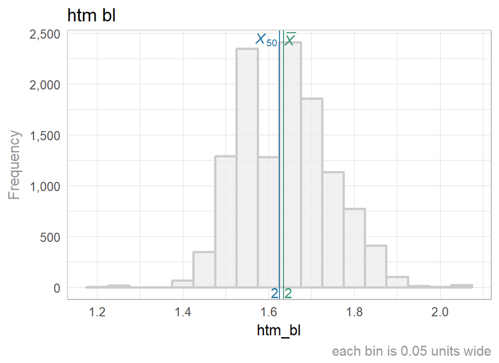

```r
# Distribution of temporally flattened measures of height
ds %>% TabularManifest::histogram_continuous("htm_bl", bin = .05)
```

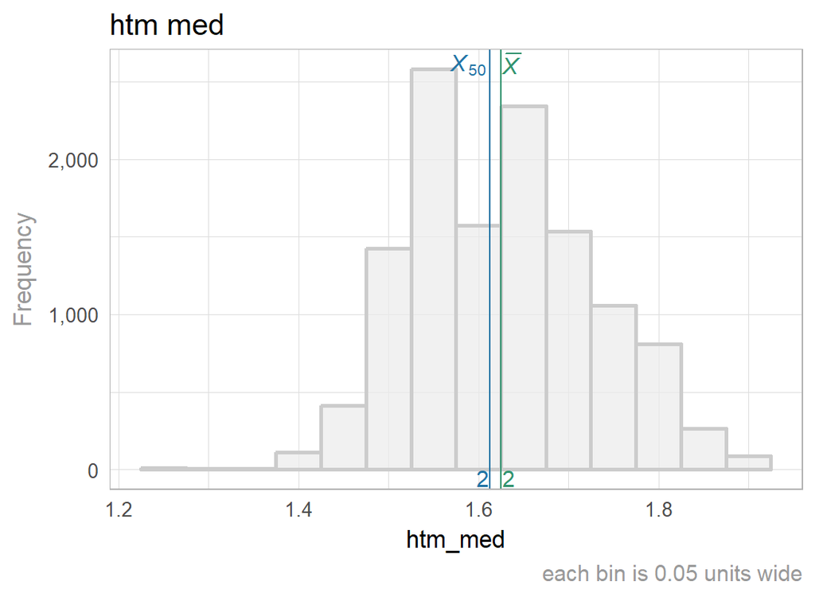

```r
ds %>% TabularManifest::histogram_continuous("htm_med", bin = .05)
```

## BMI

```r
# The measure of BMI is taken at each wave, let's reivew  data for a few cases
ds %>% view_temporal_pattern("bmi",     4)
```

```
        id wave      bmi
1 54572768    0 31.82510
2 54572768    1 31.35422
3 54572768    2 22.10701
4 54572768    5 33.20093
```

```r
ds %>% view_temporal_pattern("bmi_bl",  4)
```

```
        id wave  bmi_bl
1 54572768    0 31.8251
2 54572768    1 31.8251
3 54572768    2 31.8251
4 54572768    5 31.8251
```

```r
ds %>% view_temporal_pattern("bmi_med", 4)
```

```
        id wave  bmi_med
1 54572768    0 31.58966
2 54572768    1 31.58966
3 54572768    2 31.58966
4 54572768    5 31.58966
```

```r
# Examine ditribution of unique values and summary statistics at each wave
ds %>% dplyr::mutate(bmi     = round(bmi,0))     %>% over_waves("bmi");
```

```
Measure : bmi

       0   1   2   3   4   5   6   7   8   9  10 11 12 13 14 15 16 17 18 <NA>
  9    1   .   .   .   .   .   .   .   .   .  .  .  .  .  .  .  .  .  .  .
  11   .   .   .   .   .   .   .   .   .   1  .  .  .  .  .  .  .  .  .  .
  13   .   .   1   1   .   .   .   .   .   .  .  .  .  .  .  .  .  .  .  .
  14   5   1   1   1   .   .   .   .   .   .  .  .  .  .  .  .  .  .  .  .
  15   1   2   2   1   2   .   .   .   .   1  .  .  .  .  .  .  .  .  .  .
  16   3   4   1   1   3   1   2   1   2   2  .  1  .  .  .  .  .  .  .  .
  17   16  8   4   4   3   5   2   1   1   3  .  1  1  .  .  .  .  .  .  .
  18   21  14  11  7   6   10  11  9   3   7  5  4  3  1  .  .  .  .  .  .
  19   41  20  24  18  16  12  11  15  11  3  4  5  2  2  2  1  .  .  .  .
  20   44  34  38  37  25  19  32  19  10  13 6  6  6  2  .  .  .  .  .  .
  21   124 62  52  58  44  42  35  29  27  22 22 13 11 5  3  1  1  1  .  .
  22   174 99  86  73  62  48  44  34  29  24 18 18 15 4  2  3  .  2  .  .
```

[output cut: 39 more lines]

```
   wave  mean    sd count
1     0 27.04 5.311  2489
2     1 27.31 5.317  1522
3     2 27.22 5.307  1335
4     3 27.17 5.365  1147
5     4 27.13 5.122   962
6     5 27.11 5.414   780
7     6 26.61 5.298   629
8     7 26.84 5.305   520
9     8 26.83 5.313   391
10    9 26.89 5.743   346
11   10 27.22 5.658   268
12   11 27.20 5.458   228
13   12 26.59 5.318   152
14   13 27.08 5.307    88
15   14 26.93 5.225    40
16   15 26.30 6.036    20
17   16 28.43 6.382    14
18   17 25.44 3.005     9
19   18 26.83 2.483     6
```

```r
ds %>% dplyr::mutate(bmi_bl  = round(bmi_bl,0))  %>% over_waves("bmi_bl");
```

```
Measure : bmi_bl

       0   1   2   3   4   5  6  7  8  9  10 11 12 13 14 15 16 17 18 <NA>
  9    1   1   1   1   1   1  1  1  1  1  .  .  .  .  .  .  .  .  .  .
  14   5   1   .   .   .   .  .  .  .  .  .  .  .  .  .  .  .  .  .  .
  15   1   1   .   .   .   .  .  .  .  .  .  .  .  .  .  .  .  .  .  .
  16   3   2   2   2   1   .  .  .  .  .  .  .  .  .  .  .  .  .  .  .
  17   16  8   5   3   1   1  1  1  1  1  .  .  .  .  .  .  .  .  .  .
  18   21  13  10  9   8   9  6  6  6  5  4  4  4  2  1  1  1  1  .  .
  19   41  26  22  19  12  11 12 9  7  5  4  2  1  .  .  .  .  .  .  .
  20   44  27  25  21  16  12 14 12 6  5  5  4  3  2  1  .  .  .  .  .
  21   124 75  66  54  48  40 33 25 20 17 12 9  6  5  2  .  .  .  .  .
  22   174 105 95  81  70  55 47 44 31 25 19 15 11 9  4  2  2  2  .  .
  23   191 123 112 101 87  76 72 63 54 46 36 33 20 13 5  2  .  .  .  .
  24   201 121 109 97  88  70 60 52 36 29 25 19 9  6  4  1  1  1  .  .
```

[output cut: 30 more lines]

```
   wave  mean    sd count
1     0 27.04 5.311  2489
2     1 27.18 5.271  1565
3     2 27.24 5.311  1397
4     3 27.18 5.114  1225
5     4 27.29 5.019  1058
6     5 27.22 5.077   885
7     6 27.22 5.082   768
8     7 27.00 4.999   631
9     8 27.23 4.986   514
10    9 27.41 5.206   422
11   10 27.39 4.949   342
12   11 27.21 4.788   287
13   12 26.82 4.262   187
14   13 27.21 4.616   129
15   14 26.90 5.123    52
16   15 26.67 3.742    27
17   16 26.63 4.099    19
18   17 26.24 4.024    17
19   18 26.67 1.658     9
```

```r
ds %>% dplyr::mutate(bmi_med = round(bmi_med,0)) %>% over_waves("bmi_med");
```

```
Measure : bmi_med

       0   1   2   3   4   5  6  7  8  9  10 11 12 13 14 15 16 17 18 <NA>
  14   4   .   .   .   .   .  .  .  .  .  .  .  .  .  .  .  .  .  .  .
  15   2   2   1   1   1   .  .  .  .  .  .  .  .  .  .  .  .  .  .  .
  16   3   2   2   1   1   .  1  1  .  .  .  .  .  .  .  .  .  .  .  .
  17   17  9   7   5   1   2  1  .  1  1  .  .  .  .  .  .  .  .  .  .
  18   18  9   6   5   5   4  4  4  3  1  1  .  .  .  .  .  .  .  .  .
  19   45  29  26  24  17  16 16 12 13 9  8  7  6  3  2  1  1  1  .  .
  20   58  36  28  27  19  16 14 14 8  8  5  4  3  2  1  1  .  .  .  .
  21   116 66  58  48  47  38 32 26 19 17 13 11 6  6  2  1  1  1  .  .
  22   183 113 103 93  82  65 59 54 41 34 27 24 16 12 5  1  1  1  .  .
  23   208 136 125 110 88  76 66 56 42 37 29 24 21 13 5  2  2  2  1  .
  24   230 133 123 110 94  78 71 62 46 36 30 23 11 4  2  1  .  .  .  .
  25   241 151 135 121 107 96 74 59 45 35 26 29 19 10 3  2  2  2  1  .
```

[output cut: 27 more lines]

```
   wave  mean    sd count
1     0 26.95 5.252  2531
2     1 27.10 5.157  1592
3     2 27.18 5.221  1422
4     3 27.06 5.060  1249
5     4 27.17 4.973  1078
6     5 27.12 5.032   898
7     6 27.09 5.021   777
8     7 26.86 4.895   637
9     8 27.10 5.006   519
10    9 27.29 5.205   425
11   10 27.29 5.074   345
12   11 27.10 4.890   287
13   12 26.82 4.490   190
14   13 27.15 4.850   130
15   14 27.21 5.511    52
16   15 26.70 4.232    27
17   16 26.68 4.522    19
18   17 26.53 4.638    17
19   18 26.33 1.871     9
```

# Physical measures

## Gait

```r
# The measure of `gait` was taken at each wave, let's reivew  data for a few cases
ds %>% view_temporal_pattern("gait",     4)
```

```
        id wave      gait
1 54572768    0 0.6252308
2 54572768    1 0.4240696
3 54572768    2 0.8128000
4 54572768    5 0.5805714
```

```r
ds %>% view_temporal_pattern("gait_bl",  4)
```

```
        id wave   gait_bl
1 54572768    0 0.6252308
2 54572768    1 0.6252308
3 54572768    2 0.6252308
4 54572768    5 0.6252308
```

```r
ds %>% view_temporal_pattern("gait_med", 4)
```

```
        id wave  gait_med
1 54572768    0 0.6029011
2 54572768    1 0.6029011
3 54572768    2 0.6029011
4 54572768    5 0.6029011
```

```r
# Examine ditribution of unique values and summary statistics at each wave
ds %>% dplyr::mutate(gait     = round(gait,1))     %>% over_waves("gait");
```

```
Measure : gait

       0   1   2   3   4   5   6   7   8   9   10  11  12 13 14 15 16 17 18 <NA>
  0.1  11  4   5   2   7   3   .   2   1   3   .   2   2  .  .  1  .  .  .  .
  0.2  45  25  36  26  29  26  14  19  18  12  20  15  14 3  3  4  2  .  1  .
  0.3  174 75  86  83  74  60  53  33  45  46  37  41  34 13 4  3  1  1  .  .
  0.4  320 169 182 164 113 93  83  65  56  39  42  52  23 11 3  5  5  2  .  .
  0.5  406 267 234 207 171 131 107 81  67  42  48  38  21 10 3  2  1  1  .  .
  0.6  445 243 194 160 148 130 78  54  40  33  32  18  19 6  1  2  .  2  .  .
  0.7  345 213 170 151 117 96  66  49  26  29  27  7   7  4  1  2  .  .  .  .
  0.8  307 165 157 136 107 74  63  40  33  20  14  11  8  .  .  .  .  .  .  .
  0.9  127 79  52  56  53  25  24  17  10  5   2   1   .  .  2  .  .  .  .  .
  1    97  53  30  24  24  19  18  19  6   .   1   2   .  .  .  .  .  .  .  .
  1.1  41  27  13  10  10  6   2   2   .   1   .   .   1  .  .  .  .  .  .  .
  1.2  20  12  11  4   7   4   4   1   2   2   .   .   .  .  .  .  .  .  .  .
  1.3  4   6   4   .   2   1   .   1   .   .   .   .   .  .  .  .  .  .  .  .
  1.4  4   1   .   2   1   1   .   .   .   .   .   .   .  .  .  .  .  .  .  .
  1.5  1   1   1   .   1   .   .   .   .   .   .   .   .  .  .  .  .  .  .  .
  1.6  1   .   .   .   .   .   .   .   .   .   .   .   .  .  .  .  .  .  .  .
  1.7  .   1   .   .   .   .   .   .   .   .   .   .   .  .  .  .  .  .  .  .
  <NA> 222 262 255 230 217 232 267 256 216 193 122 100 61 83 35 8  10 11 8  .
```

```
   wave mean    sd count
1     0 0.61 0.215  2348
2     1 0.62 0.214  1341
3     2 0.59 0.210  1175
4     3 0.59 0.202  1025
5     4 0.59 0.217   864
6     5 0.58 0.206   669
7     6 0.58 0.204   512
8     7 0.57 0.214   383
9     8 0.52 0.203   304
10    9 0.51 0.200   232
11   10 0.48 0.176   223
12   11 0.44 0.169   187
13   12 0.44 0.182   129
14   13 0.43 0.140    47
15   14 0.45 0.221    17
16   15 0.39 0.176    19
17   16 0.36 0.101     9
18   17 0.47 0.121     6
19   18 0.20   NaN     1
```

```r
ds %>% dplyr::mutate(gait_bl  = round(gait_bl,1))  %>% over_waves("gait_bl");
```

```
Measure : gait_bl

       0   1   2   3   4   5   6   7   8   9  10 11 12 13 14 15 16 17 18 <NA>
  0.1  11  4   4   3   2   1   1   1   1   .  1  1  1  1  .  .  .  .  .  .
  0.2  45  15  10  10  8   7   7   4   3   3  2  2  2  1  .  .  .  .  .  .
  0.3  174 90  78  57  39  35  25  18  11  6  6  5  2  2  1  1  1  1  1  .
  0.4  320 186 160 125 101 76  71  50  42  31 17 15 10 9  2  2  2  2  1  .
  0.5  406 252 212 176 149 123 107 84  61  55 38 31 21 8  2  1  .  1  1  .
  0.6  445 283 249 223 185 164 139 112 90  78 65 45 31 20 6  4  4  4  1  .
  0.7  345 226 209 193 168 158 148 130 105 80 74 57 33 25 11 4  1  .  1  .
  0.8  307 215 196 183 171 148 118 102 85  69 53 53 35 27 11 5  5  5  3  .
  0.9  127 84  82  77  71  64  61  52  48  43 38 32 22 16 9  4  2  1  1  .
  1    97  68  66  60  56  51  43  36  36  34 28 24 15 10 3  1  1  1  .  .
  1.1  41  28  27  25  25  23  22  18  15  13 12 10 7  4  2  2  1  1  .  .
  1.2  20  14  14  13  12  13  8   9   9   7  7  8  7  4  3  3  2  1  .  .
  1.3  4   4   4   4   4   4   4   4   3   2  2  2  2  2  1  .  .  .  .  .
  1.4  4   3   3   3   2   1   1   1   1   1  1  1  1  1  1  .  .  .  .  .
  1.5  1   1   1   1   1   1   1   1   1   .  .  .  .  .  .  .  .  .  .  .
  1.6  1   1   1   1   1   1   1   1   1   1  1  1  .  .  .  .  .  .  .  .
  <NA> 222 129 114 101 86  31  22  16  8   2  .  .  1  .  .  .  .  .  .  .
```

```
   wave mean    sd count
1     0 0.61 0.215  2348
2     1 0.63 0.213  1474
3     2 0.64 0.215  1316
4     3 0.66 0.214  1154
5     4 0.67 0.214   995
6     5 0.68 0.214   870
7     6 0.68 0.213   757
8     7 0.69 0.212   623
9     8 0.71 0.215   512
10    9 0.71 0.211   423
11   10 0.73 0.213   345
12   11 0.74 0.220   287
13   12 0.74 0.225   189
14   13 0.75 0.227   130
15   14 0.80 0.225    52
16   15 0.79 0.248    27
17   16 0.76 0.256    19
18   17 0.72 0.251    17
19   18 0.64 0.207     9
```

```r
ds %>% dplyr::mutate(gait_med = round(gait_med,1)) %>% over_waves("gait_med");
```

```
Measure : gait_med

       0   1   2   3   4   5   6   7   8   9   10 11 12 13 14 15 16 17 18 <NA>
  0.1  6   1   1   1   1   1   1   .   .   .   .  .  .  .  .  .  .  .  .  .
  0.2  74  30  22  21  15  14  10  10  4   3   2  2  1  1  1  1  .  1  1  .
  0.3  231 126 112 93  81  62  50  33  28  19  14 11 8  5  1  1  1  1  .  .
  0.4  397 240 215 181 145 105 94  69  48  39  29 23 16 8  4  2  2  1  1  .
  0.5  605 397 351 305 260 217 179 148 109 92  72 61 36 25 6  2  2  2  .  .
  0.6  511 334 295 266 228 192 165 135 121 101 83 65 46 34 13 8  6  6  3  .
  0.7  364 236 219 195 180 156 143 119 105 84  65 58 34 25 11 6  4  3  2  .
  0.8  207 150 137 129 119 108 100 94  81  70  66 54 40 26 13 5  3  2  1  .
  0.9  44  30  27  24  21  22  18  16  17  16  13 13 8  6  3  2  1  1  1  .
  1    17  13  11  8   6   5   2   2   .   .   1  .  .  .  .  .  .  .  .  .
  1.1  6   5   5   4   3   2   2   1   1   .   .  .  .  .  .  .  .  .  .  .
  1.2  3   1   1   1   2   2   1   .   .   .   .  .  .  .  .  .  .  .  .  .
  <NA> 105 40  34  27  20  15  14  12  6   1   .  .  1  .  .  .  .  .  .  .
```

```
   wave mean    sd count
1     0 0.54 0.168  2465
2     1 0.56 0.164  1563
3     2 0.56 0.163  1396
4     3 0.56 0.163  1228
5     4 0.57 0.163  1061
6     5 0.58 0.164   886
7     6 0.58 0.161   765
8     7 0.59 0.158   627
9     8 0.60 0.154   514
10    9 0.61 0.152   424
11   10 0.62 0.152   345
12   11 0.62 0.152   287
13   12 0.62 0.154   189
14   13 0.63 0.150   130
15   14 0.65 0.157    52
16   15 0.63 0.171    27
17   16 0.62 0.155    19
18   17 0.59 0.178    17
19   18 0.61 0.209     9
```

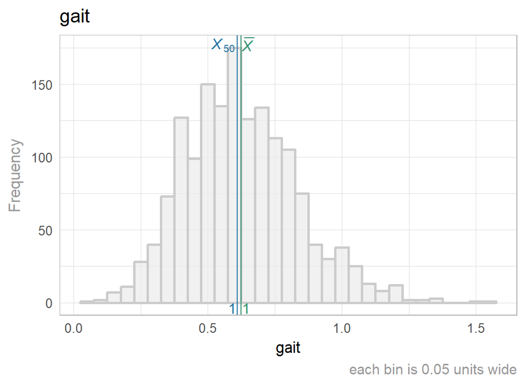

```r
# distribution of scores at baseline
ds %>%
  dplyr::filter(fu_year == 0) %>%
  TabularManifest::histogram_continuous("gait", bin_width =  .05)
```

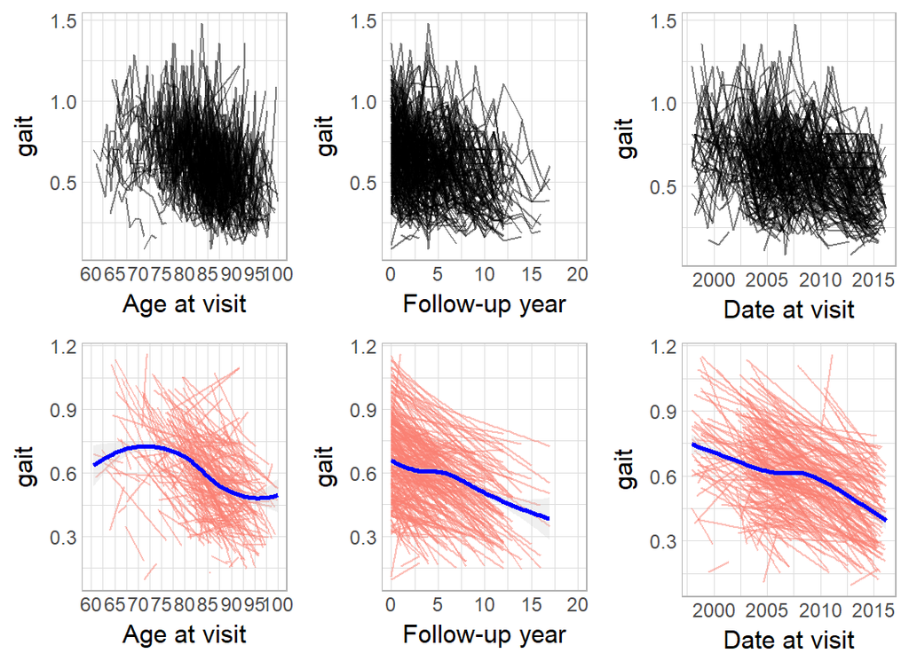

```r
# observed trajectories
ds %>%   dplyr::filter(id %in% ids) %>% raw_smooth_lines_v2( "gait")
```

## Grip

```r
# The measure of `grip` was taken at each wave, let's reivew  data for a few cases
ds %>% view_temporal_pattern("grip",     4)
```

```
        id wave  grip
1 54572768    0 48.50
2 54572768    1 40.75
3 54572768    2 44.75
4 54572768    5    NA
```

```r
ds %>% view_temporal_pattern("grip_bl",  4)
```

```
        id wave grip_bl
1 54572768    0    48.5
2 54572768    1    48.5
3 54572768    2    48.5
4 54572768    5    48.5
```

```r
ds %>% view_temporal_pattern("grip_med", 4)
```

```
        id wave grip_med
1 54572768    0    44.75
2 54572768    1    44.75
3 54572768    2    44.75
4 54572768    5    44.75
```

```r
# Examine ditribution of unique values and summary statistics at each wave
ds %>% dplyr::mutate(grip     = round(grip,0))     %>% over_waves("grip");
```

```
Measure : grip

       0   1   2   3   4   5   6   7   8   9   10  11  12 13 14 15 16 17 18 <NA>
  0    6   3   3   3   3   .   1   7   6   7   7   2   1  1  .  .  1  .  .  .
  1    .   .   1   .   1   .   .   1   .   .   .   .   .  .  .  .  .  .  .  .
  2    .   1   .   1   .   .   .   2   .   .   .   .   .  .  .  .  .  .  .  .
  3    .   .   2   .   .   .   .   .   1   .   .   .   .  .  .  .  .  .  .  .
  4    2   .   .   .   .   1   .   1   3   1   1   1   .  .  .  .  .  .  .  .
  5    4   .   1   1   .   .   .   .   .   1   1   1   .  .  .  1  .  .  .  .
  6    .   .   1   1   .   1   .   .   2   2   .   .   1  .  .  .  .  1  .  .
  7    .   .   .   .   1   3   1   2   .   .   .   .   .  .  1  .  .  .  .  .
  8    .   1   1   .   1   .   1   2   1   1   .   1   .  1  .  .  .  .  .  .
  9    4   1   .   .   1   1   1   .   1   1   .   1   1  .  .  1  .  .  .  .
  10   4   1   3   2   3   4   5   1   2   2   2   1   1  1  .  .  1  .  .  .
  11   2   5   2   .   1   1   1   2   2   1   .   .   2  1  .  .  .  .  .  .
```

[output cut: 39 more lines]

```
   wave  mean     sd count
1     0 45.97 18.265  2154
2     1 45.67 18.184  1169
3     2 44.56 18.643   989
4     3 43.57 18.330   882
5     4 42.35 17.930   631
6     5 41.44 17.948   446
7     6 40.67 17.991   369
8     7 38.16 18.263   395
9     8 38.08 18.866   398
10    9 37.80 18.602   305
11   10 37.45 18.339   235
12   11 36.50 18.501   157
13   12 35.03 17.327   114
14   13 32.22 15.035    64
15   14 32.84 11.866    25
16   15 28.48 11.784    21
17   16 28.14 15.501    14
18   17 26.25 13.625     8
19   18 22.00    NaN     1
```

```r
ds %>% dplyr::mutate(grip_bl  = round(grip_bl,0))  %>% over_waves("grip_bl");
```

```
Measure : grip_bl

       0   1   2   3   4   5   6   7   8  9  10 11 12 13 14 15 16 17 18 <NA>
  0    6   1   1   1   1   1   .   .   .  .  .  .  .  .  .  .  .  .  .  .
  4    2   1   1   1   .   1   1   1   .  1  .  .  .  .  .  .  .  .  .  .
  5    4   1   1   1   .   1   1   1   1  1  1  1  1  1  .  .  .  .  .  .
  9    4   .   .   .   .   .   .   .   .  .  .  .  .  .  .  .  .  .  .  .
  10   4   1   1   1   1   1   1   1   1  1  .  .  .  .  .  .  .  .  .  .
  11   2   1   1   .   .   .   .   .   .  .  .  .  .  .  .  .  .  .  .  .
  12   7   5   3   2   1   1   .   .   .  .  .  .  .  .  .  .  .  .  .  .
  13   2   1   .   .   .   .   .   .   .  .  .  .  .  .  .  .  .  .  .  .
  14   8   5   5   4   3   2   2   .   .  .  .  .  .  .  .  .  .  .  .  .
  15   2   1   1   1   1   .   .   .   .  .  .  .  .  .  .  .  .  .  .  .
  16   13  8   6   4   4   3   1   1   1  .  .  .  .  .  .  .  .  .  .  .
  17   2   .   .   1   1   .   .   .   .  .  .  .  .  .  .  .  .  .  .  .
```

[output cut: 39 more lines]

```
   wave  mean     sd count
1     0 45.97 18.265  2154
2     1 47.31 18.327  1397
3     2 47.54 18.307  1237
4     3 47.87 18.475  1080
5     4 48.01 18.783   919
6     5 48.99 19.099   751
7     6 49.46 18.898   645
8     7 50.52 19.296   522
9     8 51.16 19.380   425
10    9 51.72 19.461   345
11   10 52.49 18.551   272
12   11 52.75 19.426   225
13   12 52.85 19.790   138
14   13 52.48 19.597    85
15   14 58.17 19.535    23
16   15 81.00    NaN     1
```

```r
ds %>% dplyr::mutate(grip_med = round(grip_med,0)) %>% over_waves("grip_med");
```

```
Measure : grip_med

       0  1  2  3  4  5  6  7  8  9  10 11 12 13 14 15 16 17 18 <NA>
  0    12 4  4  4  4  2  1  1  1  1  1  1  .  .  .  .  .  .  .  .
  1    2  1  1  1  .  .  .  .  .  .  .  .  .  .  .  .  .  .  .  .
  2    2  1  1  1  .  1  1  1  1  1  1  1  1  1  .  .  .  .  .  .
  5    4  1  1  1  1  1  1  1  1  1  1  .  1  .  .  .  .  .  .  .
  8    4  2  2  1  1  1  1  1  1  1  .  .  .  .  .  .  .  .  .  .
  9    5  1  1  1  1  1  .  .  .  .  .  .  .  .  .  .  .  .  .  .
  10   9  4  3  2  2  1  .  .  .  .  .  .  .  .  .  .  .  .  .  .
  11   5  2  2  1  1  .  .  .  .  .  .  .  .  .  .  .  .  .  .  .
  12   4  3  2  1  .  .  .  .  .  .  .  .  .  .  .  .  .  .  .  .
  13   6  3  2  2  2  1  1  1  1  1  1  1  1  .  .  .  .  .  .  .
  14   10 6  5  4  4  4  4  3  2  2  1  1  .  .  .  .  .  .  .  .
  15   10 7  6  6  3  4  2  2  2  2  2  1  .  .  .  .  .  .  .  .
```

[output cut: 39 more lines]

```
   wave  mean     sd count
1     0 42.21 17.448  2485
2     1 43.54 17.528  1574
3     2 43.50 17.546  1415
4     3 43.36 17.578  1254
5     4 43.23 17.679  1080
6     5 43.59 17.679   901
7     6 43.53 17.269   779
8     7 43.59 17.584   639
9     8 43.75 17.837   520
10    9 43.92 17.917   425
11   10 44.38 17.567   345
12   11 44.45 17.390   287
13   12 44.55 17.389   190
14   13 44.62 17.013   130
15   14 44.79 14.459    52
16   15 41.37 12.947    27
17   16 38.42  9.530    19
18   17 38.29  9.406    17
19   18 43.22 11.809     9
```

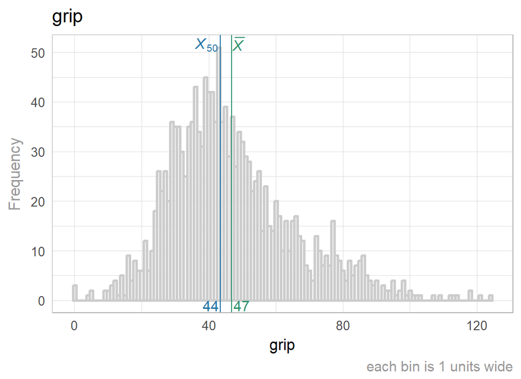

```r
# distribution of scores at baseline
ds %>%
  dplyr::filter(fu_year == 0) %>%
  TabularManifest::histogram_continuous("grip", bin_width =  1)
```

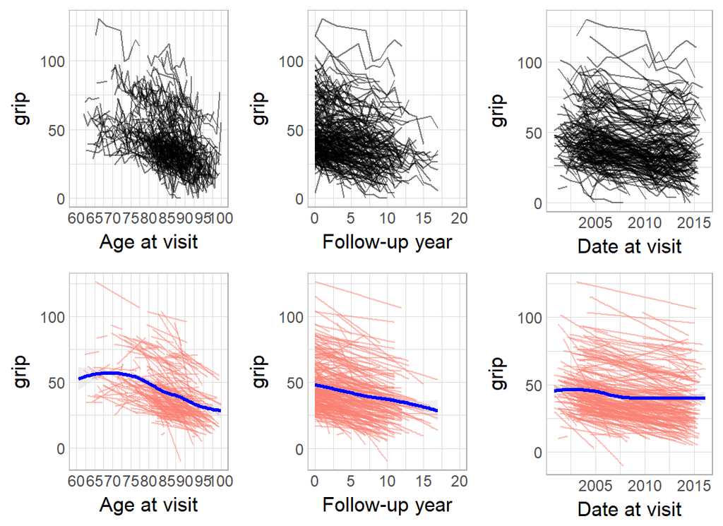

```r
# observed trajectories
ds %>%   dplyr::filter(id %in% ids) %>% raw_smooth_lines_v2( "grip")
```

# Cognitive measures

## MMSE

```r
# Examine ditribution of unique values and summary statistics at each wave
ds %>% dplyr::mutate(mmse     = round(mmse,0))     %>% over_waves("mmse");
```

```
Measure : mmse

       0   1   2   3   4   5   6   7   8  9  10 11 12 13 14 15 16 17 18 <NA>
  -2   .   4   6   3   5   6   7   3   6  4  4  5  2  3  .  1  .  1  .  .
  -1   .   19  16  12  22  14  21  18  20 13 11 5  .  2  2  .  .  .  .  .
  0    4   5   4   6   4   5   9   6   9  6  5  7  4  4  .  1  2  1  .  .
  1    2   1   1   1   1   2   4   3   1  1  .  1  3  1  .  .  .  1  1  .
  2    2   .   .   2   2   3   2   1   .  .  2  .  2  2  2  .  .  .  .  .
  3    .   1   1   1   2   4   2   3   1  3  1  1  .  1  .  .  .  .  .  .
  4    1   .   4   1   1   2   1   2   2  2  .  2  2  .  1  .  .  .  .  .
  5    2   .   2   1   .   .   1   3   1  1  .  4  .  3  .  .  .  .  .  .
  6    1   .   1   2   1   2   2   .   3  .  1  1  1  1  .  .  .  .  .  .
  7    .   .   1   3   4   2   3   3   .  2  1  1  .  .  .  .  .  1  .  .
  8    .   1   1   6   3   2   3   .   3  .  3  2  3  1  .  .  .  .  .  .
  9    3   2   2   7   4   7   2   2   3  1  6  4  1  1  .  .  .  .  .  .
```

[output cut: 22 more lines]

```
   wave  mean     sd count
1     0 27.38  3.559  1728
2     1 26.93  4.930  1603
3     2 26.57  5.363  1430
4     3 26.31  5.607  1255
5     4 25.77  6.472  1081
6     5 25.47  6.825   901
7     6 24.79  7.755   779
8     7 24.67  7.593   639
9     8 24.05  8.464   520
10    9 24.40  8.082   425
11   10 23.74  8.430   345
12   11 23.78  8.606   287
13   12 24.03  8.176   190
14   13 22.65  9.551   130
15   14 24.06  8.361    52
16   15 23.52  8.772    27
17   16 21.84  9.002    19
18   17 19.88 11.779    17
19   18 21.33 10.607     9
```

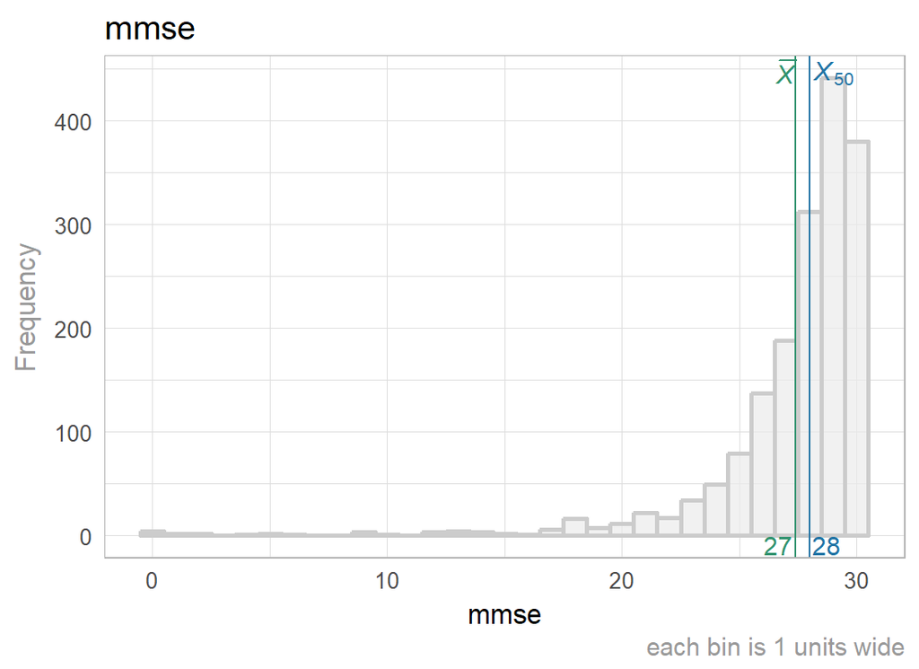

```r
# distribution of scores at baseline
ds %>%
  dplyr::filter(fu_year == 0) %>%
  TabularManifest::histogram_continuous("mmse", bin_width = 1)
```

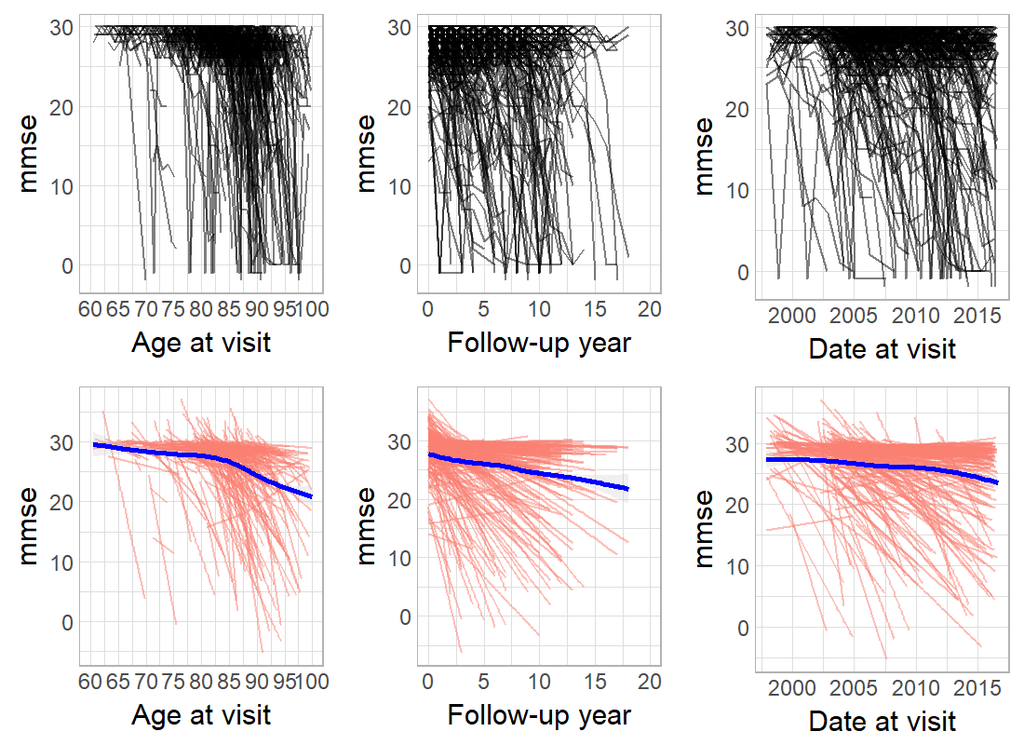

```r
# observed trajectories
ds %>%   dplyr::filter(id %in% ids) %>% raw_smooth_lines_v2( "mmse")
```

## Global cognition

```r
ds %>%
  dplyr::select(id,fu_year, cogn_global) %>%
  dplyr::filter(!is.na(cogn_global)) %>%
  dplyr::group_by(fu_year) %>%
  dplyr::summarize(average_global_cognition = round(mean(cogn_global),3),
                   sd = sprintf("%0.2f",sd(cogn_global)),
                   observed_n =n())
```

```
# A tibble: 20 x 4
   fu_year average_global_cognition sd    observed_n
     <dbl>                    <dbl> <chr>      <int>
 1    0                    -0.00200 0.67        1722
 2    1.00                  0.0280  0.68        1578
 3    2.00                  0.0140  0.73        1406
 4    3.00                  0.0100  0.76        1230
 5    4.00                 -0.0450  0.81        1053
 6    5.00                 -0.0500  0.84         872
 7    6.00                 -0.0930  0.87         749
 8    7.00                 -0.129   0.87         613
 9    8.00                 -0.150   0.88         491
10    9.00                 -0.0950  0.85         401
11   10.0                  -0.117   0.90         327
12   11.0                  -0.179   0.98         267
13   12.0                  -0.194   0.99         182
14   13.0                  -0.290   1.11         120
15   14.0                  -0.125   1.05          49
16   15.0                  -0.271   1.08          25
17   16.0                  -0.293   0.91          17
18   17.0                  -0.333   1.22          14
19   18.0                  -0.115   1.19           7
20   NA                    -0.222   0.71         836
```

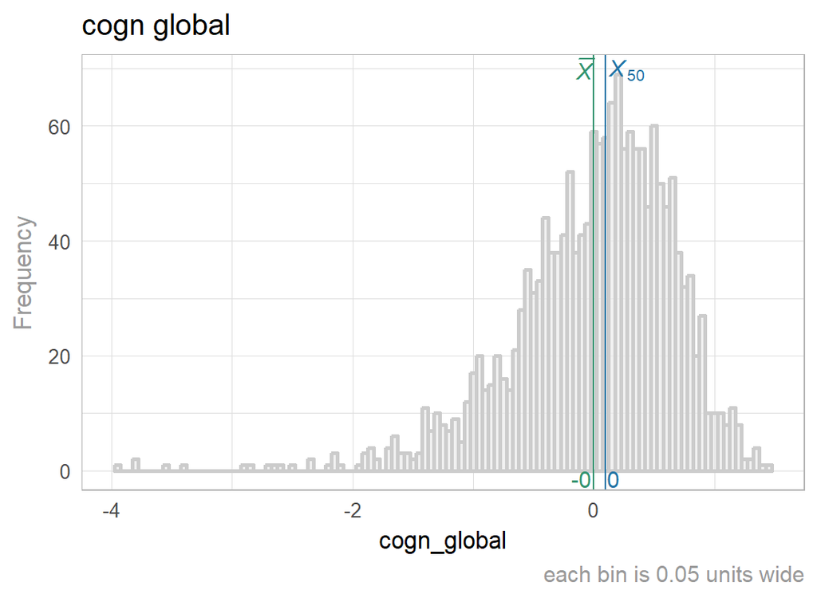

```r
# distribution of scores at baseline
ds %>%
  dplyr::filter(fu_year == 0) %>%
  TabularManifest::histogram_continuous("cogn_global", bin_width =  .05)
```

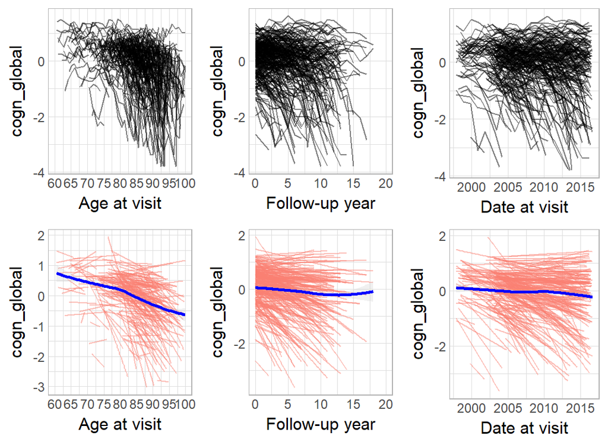

```r
ds %>%
  dplyr::filter(id %in% ids) %>%
  raw_smooth_lines_v2("cogn_global")
```

## Dementia

```r
dd <- ds %>%
  dplyr::filter(!is.na(dementia)) %>%
  dplyr::group_by_("fu_year") %>%
  dplyr::summarize(percent_diagnosed=mean(dementia),
                   observed_n = n())
dd
```

```
# A tibble: 20 x 3
   fu_year percent_diagnosed observed_n
     <dbl>             <dbl>      <int>
 1    0               0.0533       1727
 2    1.00            0.0666       1576
 3    2.00            0.0950       1410
 4    3.00            0.109        1237
 5    4.00            0.123        1057
 6    5.00            0.135         887
 7    6.00            0.140         758
 8    7.00            0.177         623
 9    8.00            0.187         507
10    9.00            0.176         415
11   10.0             0.179         335
12   11.0             0.209         268
13   12.0             0.216         185
14   13.0             0.241         108
15   14.0             0.256          43
16   15.0             0.269          26
17   16.0             0.368          19
18   17.0             0.333          15
19   18.0             0.400           5
20   NA               0.0951        841
```

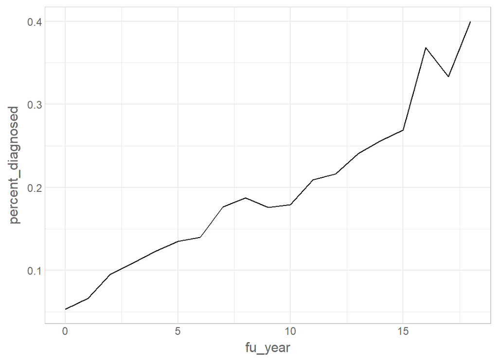

```r
g <- ggplot2::ggplot(dd, aes_string(x="fu_year",y="percent_diagnosed"))
g <- g + geom_line(na.rm = T)
g <- g + main_theme
g
```

```r
dd <- ds %>%
  dplyr::filter(!is.na(dementia)) %>%
  dplyr::mutate(age_cat = cut(age_at_visit,breaks = 10)) %>%
  dplyr::group_by_("age_cat") %>%
  dplyr::summarize(percent_diagnosed=mean(dementia),
                   observed_n = n())
dd
```

```
# A tibble: 10 x 3
   age_cat     percent_diagnosed observed_n
   <fct>                   <dbl>      <int>
 1 (53.3,58.8]           0               30
 2 (58.8,64.2]           0.00813        123
 3 (64.2,69.7]           0.0222         496
 4 (69.7,75.2]           0.0389        1028
 5 (75.2,80.6]           0.0519        2102
 6 (80.6,86.1]           0.0897        3379
 7 (86.1,91.5]           0.162         3179
 8 (91.5,97]             0.230         1385
 9 (97,102]              0.304          303
10 (102,108]             0.294           17
```

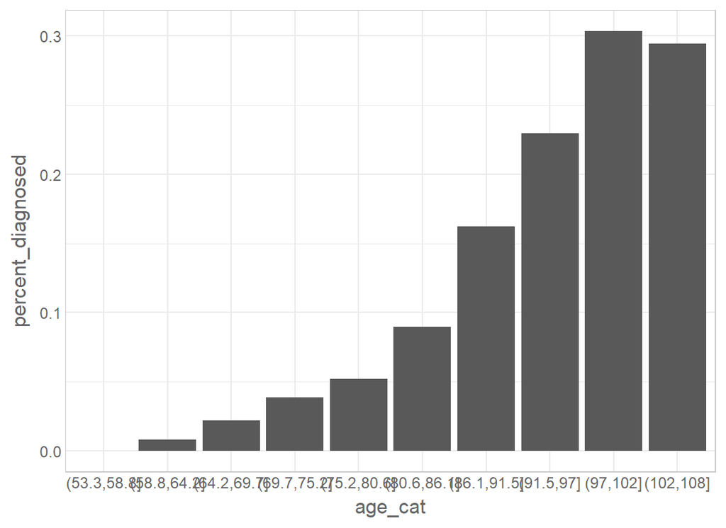

```r
g <- ggplot2::ggplot(dd, aes_string(x="age_cat",y="percent_diagnosed"))
g <- g + geom_bar(stat="identity")
g <- g + main_theme
g
```